```python
import pylab as pl
from  numpy.random import normal
import numpy as np
import healpy as hp
from scipy  import  signal
from scipy.signal import periodogram

from pylab import cm
cmap = cm.get_cmap('RdYlBu')
cmap.set_under('w')
from __future__ import print_function
from ipywidgets import interact, interactive, fixed, interact_manual
import ipywidgets as widgets
```

```python
from IPython.display import HTML

HTML('''<script>
code_show=true;
function code_toggle() {
 if (code_show){
 $('div.input').hide();
 } else {
 $('div.input').show();
 }
 code_show = !code_show
}
$( document ).ready(code_toggle);
</script>
<form action="javascript:code_toggle()"><input type="submit" value="Click here to toggle on/off the raw code."></form>''')
```

# 1. Constant gain mismatches at a given time scale $\tau$

In previous posting I've found that the gain estimate procedure worked properly if we injected gain mismatches as a constant fluctuation around 1 and with a certain width ($\sigma_g$ ) **on just one detector** per detector pair.

The input maps related to those kind of studies encoded mostly the Dipole and CMB fluctuations (only scalar anisotropies). However, we didn't test that procedure when the signal leaking into polarization encoded a larger thermal load: as the CMB Monopole for a satellite.

Below the parameters used in Toast simulations:

- Noise simulated :True
- Detector pairs: 2
- T_obs : 1 yr
- sampling freq: 20 Hz
- precession period :96.1803 min
- spin period: 10 min
- HWP : False
- spin angle : 50
- precession angle :45
- MADAM destriper (baseline=60 sec)
- Input maps: Monopole, Dipole, CMB T

We therefore tried several cases by changing the mismatch time scale, $\tau$ and $\sigma_g$.

The procedure to mitigate gain mismatches is performed on each chunck (related to $\tau$) of time samples $d_{t , t+\tau}$ of a given detector:

1. Apply a high-pass filter to $d_{t , t+\tau} $ with cutoff frequency $f_{c}=10$ mHz
2. Regress $d_{t , t+\tau} $ against signal-only template $T$ and estimate the regression slope $\hat{g}$ as $$ \hat{g} = \frac { T^{t} d } { T^{t} T } $$
3. Mitigate the leakage, dividing $d_{t , t+\tau} $ by $\hat{g}$
4. Estimate maps after mitigation

```python
folder = '/Users/peppe/work/satellite_sims/drifting_gain/monopole/'

g_sh_sm  = pl.load(folder+'gains_1min_5em4.npy')[::2]
g_lo_lar   = pl.load(folder+'gains_10min_5em3.npy')[::2]
g_sh_lar   = pl.load(folder+'gains_1min_5em3.npy')[::2]
g_lo_sm  = pl.load(folder+'gains_10min_5em4.npy')[::2]
```

```python
ge_sh_sm  = pl.load(folder+'gains_coeff_1min_5em4.npy')[:,0]
ge_lo_lar   = pl.load(folder+'gains_coeff_10min_5em3.npy')[:,0]
ge_sh_lar   = pl.load(folder+'gains_coeff_1min_5em3.npy')[:,0]
ge_lo_sm  = pl.load(folder+'gains_coeff_10min_5em4.npy')[:,0]
```

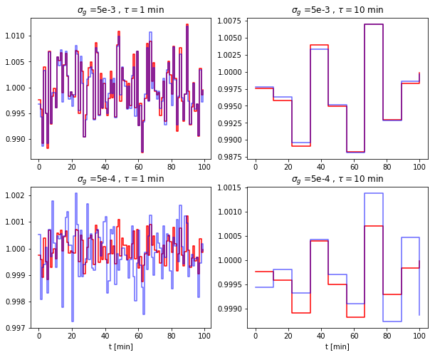

```python
N = 100
pl.figure(figsize=(10,8))

pl.subplot(221)
pl.title(r'$\sigma_g$ =5e-3 , $\tau=1$ min')
pl.step( g_sh_lar[:N] , 'r' , where='post')
pl.step( ge_sh_lar[:N] , 'b--', alpha=.6 , where='post')
pl.subplot(222)
pl.title(r'$\sigma_g$ =5e-3 , $\tau=10$ min')

pl.step( pl.linspace(0,N, N/10), g_lo_lar[ :N/10] , 'r', where='post' )
pl.step( pl.linspace(0,N, N/10),ge_lo_lar[ :N/10] , 'b--', alpha=.6 , where='post')
pl.subplot(223)
pl.title(r'$\sigma_g$ =5e-4 , $\tau=1$ min')

pl.step( g_sh_sm[:N ] , 'r' , where='post')
pl.step( ge_sh_sm[:N ] , 'b--', alpha=.6 , where='post')
pl.xlabel('t [min]')
pl.subplot(224)
pl.title(r'$\sigma_g$ =5e-4 , $\tau=10$ min')

pl.step( pl.linspace(0,N, N/10),g_lo_sm[:N/10 ] , 'r', where='post' )
pl.step( pl.linspace(0,N, N/10),ge_lo_sm[:N /10] , 'b--', alpha=.6, where='post' )
pl.xlabel('t [min]')
```

We 've found that we are able to track the gain mismatches pretty well except when both $\sigma_g$ and $\tau$ are small. To better quantify this, we can estimate the correlation index $\rho$ between the true underlying gain mismatches and the gain estimates. The closer $\rho$ is to 1, the more the estimates are correlated to the true ones, hence the better are the performance of the gain estimates.

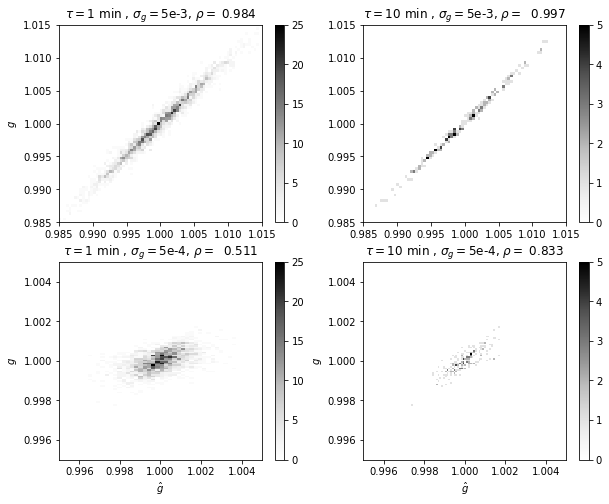

```python
import scipy.stats as spt

rshlar= spt.linregress(g_sh_lar,ge_sh_lar)[2]
rshsm= spt.linregress(g_sh_sm,ge_sh_sm)[2]
rlolar= spt.linregress(g_lo_lar,ge_lo_lar)[2]
rlosm= spt.linregress(g_lo_sm,ge_lo_sm)[2]
pl.figure(figsize=(10,8))
pl.subplot(221)
pl.title( r'$\tau =$1 min , $\sigma_g=$5e-3, $\rho=$ {:.3f}'.format(rshlar))
pl.hist2d(ge_sh_lar,g_sh_lar, bins= 100 ,  cmap=pl.cm.Greys,);pl.colorbar()
pl.ylabel(r'$g$')

pl.xlim([1-0.015 ,1+0.015])
pl.ylim([1-0.015 ,1+0.015])

pl.subplot(222)
pl.title(r'$\tau =$10 min , $\sigma_g=$5e-3, $\rho=$  {:.3f}'.format(rlolar) )
pl.hist2d(ge_lo_lar, g_lo_lar, bins= 100 ,  cmap=pl.cm.Greys , vmax=5 );pl.colorbar()
pl.xlim([1-0.015 ,1+0.015])
pl.ylim([1-0.015 ,1+0.015])
pl.subplot(223)
pl.hist2d(ge_sh_sm,g_sh_sm, bins= 50  , cmap=pl.cm.Greys );pl.colorbar()
pl.title(r'$\tau =$1 min , $\sigma_g=$5e-4, $\rho=$  {:.3f}'.format(rshsm))

pl.xlim([1-0.005 ,1+0.005])
pl.ylim([1-0.005 ,1+0.005])
pl.ylabel(r'$g$')
pl.xlabel(r'$\hat{g}$')
pl.subplot(224)
pl.title(r'$\tau =$10 min , $\sigma_g=$5e-4, $\rho=$ {:.3f}'.format(rlosm) )

pl.hist2d(ge_lo_sm, g_lo_sm,bins= 50  , cmap=pl.cm.Greys, vmax=5);pl.colorbar()
pl.xlim([1-0.005 ,1+0.005])
pl.ylim([1-0.005 ,1+0.005])
pl.ylabel(r'$g$')
pl.xlabel(r'$\hat{g}$')
```

**Fig2** 2D Histrogram of scatter plot of the true gain mismatches vs. the gain estimates. The histograms are not normalized, so that the colorscale indicates how many points fall into each bin. The number of bins is chosen accordingly to the width of gain fluctuations, for top (bottom) panels being $N_{bins}=100 (50)$. AS already stated above, the larger is $\tau $, the more the estimates are correlated with the underlying ones, meaning that is better to estimate the gains on a larger timescale.

## summary

# 2. Gain drifting with time with a $1/f $ dependence

Now we complicate a bit further the simulations and we inject a gain drift on the signal sampled by each detector in a detector pair. The drift is described by a low frequency signal, $<1 $ mHz, with a 1/f spectrum ($f_{knee}=150$ mHz).

We keep the very same TOAST simulation parameters and the gain estimate procedure as sketched above and compare the gain estimates by changing $\tau$ and $\sigma_g$.

```python
d_lo_lar = pl.load('/Users/peppe/work/satellite_sims/drifting_gain/monopole/gains_lpf1mHz_1em4.npy')[0,: ]
d_lo_sm = pl.load('/Users/peppe/work/satellite_sims/drifting_gain/monopole/gains_lpf1mHz_1em5.npy')[0,: ]
d_sh_sm = pl.load('/Users/peppe/work/satellite_sims/drifting_gain/monopole/gains_short_lpf1mHz_1em4.npy')[0,: ]
d_sh_lar = pl.load('/Users/peppe/work/satellite_sims/drifting_gain/monopole/gains_short_lpf1mHz_1em3.npy')[0,: ]

de_lo_lar= pl.load('/Users/peppe/work/satellite_sims/drifting_gain/monopole/gains_coeff_lpf1mHz_1em4.npy')[ :,0 ]
de_lo_sm= pl.load('/Users/peppe/work/satellite_sims/drifting_gain/monopole/gains_coeff_lpf1mHz_1em5.npy')[ :,0 ]
de_sh_sm= pl.load('/Users/peppe/work/satellite_sims/drifting_gain/monopole/gains_coeff_short_lpf1mHz_1em4.npy')[ :,0 ]
de_sh_lar= pl.load('/Users/peppe/work/satellite_sims/drifting_gain/monopole/gains_coeff_short_lpf1mHz_1em3.npy')[ :,0 ]
```

```python
tau_long = 0.1603005 *60.
tau_short = 0.01603005 *60.
Nlong = len(d_lo_lar )
Nchunkslong = len(de_lo_lar)
tlo  =pl.arange(Nlong)/20/60
tblo = pl.linspace(0,(Nchunkslong +1)  *tau_long   , Nchunkslong  )
```

```python
Nshort = len(d_sh_sm )

Nchunksshort = len(de_sh_sm)
tsh  =pl.arange(Nshort)/20/60
tbsh= pl.linspace(0,(Nchunksshort +1)  *tau_short   , Nchunksshort  )
```

```python
Nshort2 = len(d_sh_lar)

Nchunksshort2 = len(de_sh_lar)
tsh2  =pl.arange(Nshort2)/20/60
tbsh2= pl.linspace(0,(Nchunksshort2 +1)  *tau_short  , Nchunksshort2  )
```

```
(0.975, 1.025)
```

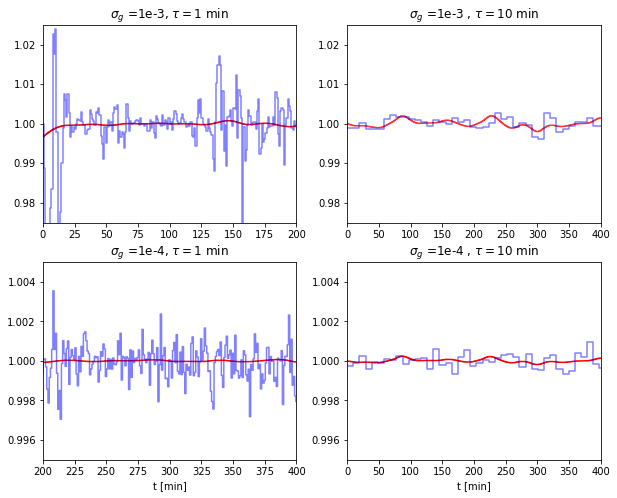

```python
pl.figure(figsize=(10,8))

pl.subplot(222)
pl.title(r'$\sigma_g$ =1e-3 , $\tau=10$ min')


pl.plot(tlo ,  (d_lo_lar  +1  ) , 'r', alpha=.8 )
pl.step( tblo , de_lo_lar,'b', where='post',  alpha=.5)
pl.xlim([ 0,5])
pl.ylim([ .975,1.025])

pl.xlim([ 0,400])
pl.subplot(224)
pl.title(r'$\sigma_g$ =1e-4 , $\tau=10$ min')

pl.plot(tlo,  (d_lo_sm  +1  ) ,'r' ) ;
pl.step( tblo , de_lo_sm,'b',  where='post',  alpha=.5)
pl.xlabel('t [min]')
pl.xlim([0,400])
pl.ylim([0.995,1.005])
pl.subplot(223)
pl.xlabel('t [min]')
pl.title(r'$\sigma_g$ =1e-4, $\tau=1$ min')

pl.plot(tsh,  (d_sh_sm   +1  ) , 'r' ) ;
pl.step( tbsh , de_sh_sm,'b',  where='post',  alpha=.5)
pl.xlim([ 200,400])
pl.ylim([0.995,1.005])

pl.subplot(221)
pl.title(r'$\sigma_g$ =1e-3, $\tau=1$ min')

pl.plot(tsh2,  (d_sh_lar  +1  ) , 'r' ) ;
pl.step( tbsh2,   de_sh_lar,'b',  where='post',  alpha=.5)
pl.xlim([  0,200])
pl.ylim([ .975,1.025])
```

**Fig3** (solid red) gain drifts injected into the TODs and their estimates (solid blue) for different choices of $\sigma_g = 0.1 (0.01) % $ in the top (bottom) rows and $\tau =$ 1 (10) min in the left (right) columns.

## Summary

If compared with Fig1 above we notice that we are more able to track the gain drifts with a larger $\sigma_g$ and with a longer $\tau$. As pointed out previously, without highpass filtering the data, the gain estimates tracks perfectly both gain drifts and mismatches (Also, I've checked that the presence of noise doesn't affect the gain estimates)

These results might lead to the following conclusions:

- Given $\sigma_g$, the signal leaking to polarization comes mostly from Monopole and CMB Dipole $\sim 1$ K , and its amplitude will be proportional to $ \sigma_g $, $\sim \mathcal{O}(\sigma_g) $ K
- When we High-pass filter the data, we essentially filter all the low frequency signals in the data, and the amplitude of polarized leaked signal is at most at the same order of magnitude of the filtered signal ( i.e. just the CMB Temperature anisotropies ) both on Q and U maps . In the figure below you see indeed that the mitigation technique works fairly well when we increase $\sigma_g$ to the level of $1\%$
- As a result, the gain estimates are noisy especially when the gain is drifting, or when we estimate the gain on shorter time scales.

```
(0.8, 1.2)
```

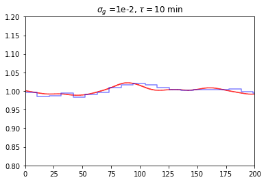

```python
d_lo_vlar = pl.load('/Users/peppe/work/satellite_sims/drifting_gain/monopole/gains_lpf1mHz_1em3.npy')[0,: ]
de_lo_vlar= pl.load('/Users/peppe/work/satellite_sims/drifting_gain/monopole/gains_coeff_lpf1mHz_1em3.npy')[ :,0 ]

Nlong = len(d_lo_vlar )
Nchunkslong = len(de_lo_vlar)
tlo  =pl.arange(Nlong)/20/60
tblo = pl.linspace(0,(Nchunkslong +1)  *tau_long   , Nchunkslong  )
pl.plot(tlo ,  (d_lo_vlar  +1  ) , 'r', alpha=.8 )
pl.step( tblo , de_lo_vlar,'b', where='post',  alpha=.5)
pl.title(r'$\sigma_g$ =1e-2, $\tau=10$ min')
pl.xlim([  0,200])
pl.ylim([ .8,1.2])
```